# Introduction to R

### Correlation (Continued)

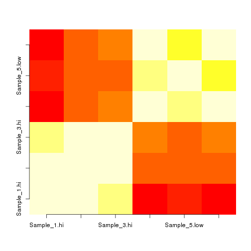

```r
image(cor(minRep),axes=F)
axis(1,at=seq(0,1,length.out=6),colnames(minRep))
axis(2,at=seq(0,1,length.out=6),colnames(minRep))
```

### Distributions

R comes with functions for extracting information from most common distibutions types. An example of standard R functions for dealing with distibution can be seen here using the normal distributions.

- pnorm - cumulative distribution for x
- qnorm - inverse of pnorm (from probability gives x)
- dnorm - distribution density
- rnorm - random number from normal distribution

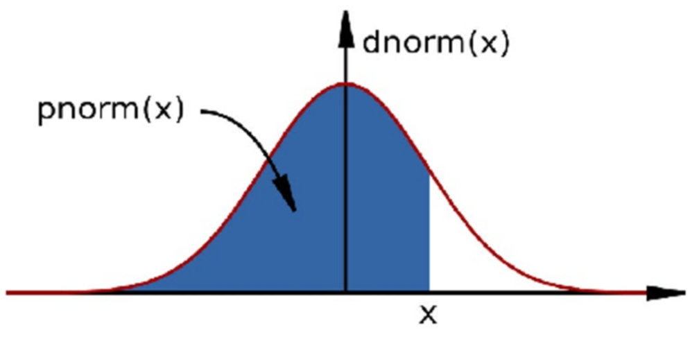

Similar functions are available for other distibution types including:

- pbinom (binomial)
- pnbinom (negative binomial),
- phyper (hyper-geometric)
- pt (T distribution)

### Distributions (Examples)

We can use rnorm to generate random values following a nromal distribution. Here we produce 10 normally distributed values numeric values with mean 8 and standard deviation of 3

```r
rnorm(10,mean=8,sd=3)
```

```
 [1] 8.847 6.899 4.877 8.821 9.797 2.975 9.284 7.864 6.294 8.426
```

We can also use these functions to interrogate values assuming a normal distribution for the data.

The probablity of a value being exactly 8 for a distribution of mean 8 and standard deviation 3.

```r
dnorm(8,mean=8,sd=3)
```

```
[1] 0.133
```

The probablity of a value being less than 8 for a distribution of mean 8 and standard deviation 3.

```r
pnorm(8,mean=8,sd=3)
```

```
[1] 0.5
```

The value for which i have a 50 percent being greater than given a normal distribution of mean 8 and standard deviation 3.

```r
qnorm(0.5,mean=8,sd=3)
```

```
[1] 8
```

### Statistical tests

On top of descriptive statistics, R has several statistical tests covering a range of problems and data types.

Some of the most used tests of two samples include:

- var.test() - Comparing 2 variances (Fisher's F test)
- t.test() - Comparing 2 sample means with normal errors (Student's t-test)
- wilcox.test() - Comparing 2 means with non-normal errors (Wilcoxon's rank test)
- fisher.test() - Testing for independence of 2 variables in a contingency table (Fisher's exact test)

### T-test example

To perform a t-test we will generate some datasets, test that the variances of the datasets are equal and then perform the actual t-tests.

First lets produce the data using rnorm()

```r
groupA <- rnorm(10,mean=26,sd=1)
groupB <- rnorm(10,mean=40,sd=1)
groupC <- rnorm(10,mean=40,sd=4)

tTestExample <- data.frame(A=groupA,B=groupB,C=groupC)

tTestExample
```

```
       A     B     C
1  23.81 40.84 37.00
2  24.98 40.06 39.70
3  25.80 38.68 42.80
4  24.06 40.64 41.58
5  26.68 37.92 39.49
6  25.93 42.47 35.41
7  25.44 39.38 44.06
8  25.44 40.14 40.12
9  26.59 40.34 44.60
10 26.14 39.35 44.60
```

### T-test example

First lets retrieve the variance of columns using var().

```r
var(tTestExample$A)
```

```
[1] 0.9419
```

```r
var(tTestExample$B)
```

```
[1] 1.578
```

```r
var(tTestExample$C)
```

```
[1] 10.09
```

Now we can test for any differences in variance between A and B and A and C.

```r
var.test(tTestExample$A,tTestExample$B)
```

```
    F test to compare two variances

data:  tTestExample$A and tTestExample$B
F = 0.5969, num df = 9, denom df = 9, p-value = 0.454
alternative hypothesis: true ratio of variances is not equal to 1
95 percent confidence interval:
 0.1483 2.4032
sample estimates:
ratio of variances
            0.5969
```

```r
var.test(tTestExample$A,tTestExample$C)
```

```
    F test to compare two variances

data:  tTestExample$A and tTestExample$C
F = 0.0934, num df = 9, denom df = 9, p-value = 0.001598
alternative hypothesis: true ratio of variances is not equal to 1
95 percent confidence interval:
 0.02319 0.37585
sample estimates:
ratio of variances
           0.09336
```

### T-test example

Now we have ascertained that GroupA and GroupB have similar variances. We can therefore perform a standard t-test to assess the significance of differences betweem the groups.

```r
Result <- t.test(tTestExample$A,tTestExample$B,alternative ="two.sided",
                 var.equal = T)
Result
```

```
    Two Sample t-test

data:  tTestExample$A and tTestExample$B
t = -28.87, df = 18, p-value < 2.2e-16
alternative hypothesis: true difference in means is not equal to 0
95 percent confidence interval:
 -15.55 -13.44
sample estimates:
mean of x mean of y
    25.49     39.98
```

To compare groups of unequal variance then the var.equal argument may be set to FALSE (which is the default).

```r
Result <- t.test(tTestExample$A,tTestExample$C,alternative ="two.sided",
                 var.equal = F)
Result
```

```
    Welch Two Sample t-test

data:  tTestExample$A and tTestExample$C
t = -14.71, df = 10.67, p-value = 2.013e-08
alternative hypothesis: true difference in means is not equal to 0
95 percent confidence interval:
 -17.77 -13.13
sample estimates:
mean of x mean of y
    25.49     40.94
```

### T-test example

The same result to that shown could be achieved by specify a formula for the comparison. Here we wish to compare column A versus B so we could simply specify the formula and the data to be used.

```r
longFrame <- data.frame(Group = c(rep("A",nrow(tTestExample)),rep("B",nrow(tTestExample)))
                          ,Value=c(tTestExample$A,tTestExample$B))

Result <- t.test(Value~Group,longFrame,alternative ="two.sided",
                 var.equal = T)
Result
```

```
    Two Sample t-test

data:  Value by Group
t = -28.87, df = 18, p-value < 2.2e-16
alternative hypothesis: true difference in means is not equal to 0
95 percent confidence interval:
 -15.55 -13.44
sample estimates:
mean in group A mean in group B
          25.49           39.98
```

### Regression and linear models

We have seem how we can find the correlation between two sets of variables using cor() function.

R also provides a comprehensive set of tools for regression analysis including the well used linear modelling function lm()

To fit a linear regression we use a similar set of arguments as passed to the t-test fuction in the previous slide.

```r
> x=rnorm(100,70,10)
> y <- jitter(x,amount=40)+20
> lmExample <- data.frame(X=x,Y=y)
```

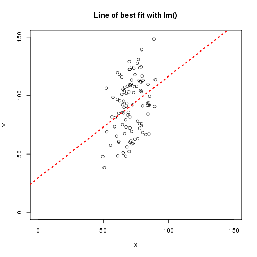

```r
> lmResult <- lm(Y~X,data=lmExample)
> plot(Y~X,data=lmExample,main="Line of best fit with lm()",
+      xlim=c(0,150),ylim=c(0,150))
> abline(lmResult,col="red",lty=3,lwd=3)
```

### The lm() function

The lm() function fits a linear regression to your data and provides useful information on the generated fit.

In the example below we fit a linear model using lm() on the lmExample dataset with column Y as the dependent variable and column X as the explanatory variable.

```r
> lmResult <- lm(Y~X,data=lmExample)
> lmResult
```

```
Call:
lm(formula = Y ~ X, data = lmExample)

Coefficients:
(Intercept)            X
      29.44         0.87
```

Printing the result from lm() shows the call to lm() and the coefficients including the intercept.

From this we know the formula for the line.

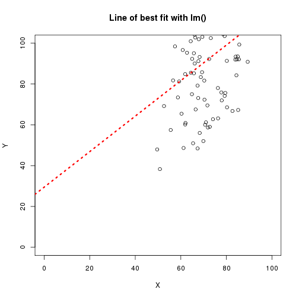

```r
> plot(Y~X,data=lmExample,main="Line of best fit with lm()",
+      xlim=c(0,100),ylim=c(0,100))
> abline(lmResult,col="red",lty=3,lwd=3)
```

### Interpreting output of lm()

As we have seen, printing the model result provides the intercept and slope of line.

To get some more information on the model we can use the summary() function

```r
> summary(lmResult)
```

```
Call:
lm(formula = Y ~ X, data = lmExample)

Residuals:
   Min     1Q Median     3Q    Max
-39.66 -18.93   2.15  17.28  41.56

Coefficients:
            Estimate Std. Error t value Pr(>|t|)
(Intercept)   29.444     18.112    1.63  0.10724
X              0.870      0.252    3.45  0.00082 ***
---
Signif. codes:  0 '***' 0.001 '**' 0.01 '*' 0.05 '.' 0.1 ' ' 1

Residual standard error: 22.5 on 98 degrees of freedom
Multiple R-squared:  0.108, Adjusted R-squared:  0.0993
F-statistic: 11.9 on 1 and 98 DF,  p-value: 0.000824
```

### Interpreting output of lm() (Residuals...)

```
Call:
lm(formula = Y ~ X, data = lmExample)

Residuals:
   Min     1Q Median     3Q    Max
-39.66 -18.93   2.15  17.28  41.56

Coefficients:
            Estimate Std. Error t value Pr(>|t|)
(Intercept)   29.444     18.112    1.63  0.10724
X              0.870      0.252    3.45  0.00082 ***
---
Signif. codes:  0 '***' 0.001 '**' 0.01 '*' 0.05 '.' 0.1 ' ' 1

Residual standard error: 22.5 on 98 degrees of freedom
Multiple R-squared:  0.108, Adjusted R-squared:  0.0993
F-statistic: 11.9 on 1 and 98 DF,  p-value: 0.000824
```

The **residuals** are the difference between the predicted line. To retrieve the residuals we can access the slot or use the resid() function.

```r
> summary(resid(lmResult))
```

```
   Min. 1st Qu.  Median    Mean 3rd Qu.    Max.
 -39.70  -18.90    2.15    0.00   17.30   41.60
```

```r
> summary(lmResult$residual)
```

```
   Min. 1st Qu.  Median    Mean 3rd Qu.    Max.
 -39.70  -18.90    2.15    0.00   17.30   41.60
```

Ideally you would want your residuals to be normally distributed around 0 indicating a good correspondence between predicted and actual values.

### Interpreting output of lm() (R-squared...)

```
Call:
lm(formula = Y ~ X, data = lmExample)

Residuals:
   Min     1Q Median     3Q    Max
-39.66 -18.93   2.15  17.28  41.56

Coefficients:
            Estimate Std. Error t value Pr(>|t|)
(Intercept)   29.444     18.112    1.63  0.10724
X              0.870      0.252    3.45  0.00082 ***
---
Signif. codes:  0 '***' 0.001 '**' 0.01 '*' 0.05 '.' 0.1 ' ' 1

Residual standard error: 22.5 on 98 degrees of freedom
Multiple R-squared:  0.108, Adjusted R-squared:  0.0993
F-statistic: 11.9 on 1 and 98 DF,  p-value: 0.000824
```

The **R-squared** value represents the proportion of variability in the response variable that is explained by the explanatory variable.

A high **R-squared** value indicates a good correspondence between the predictor and dependent variables.

### Interpreting output of lm() (Per variable p-values and the F-statistic)

```r
> summary(lmResult)
```

```
Call:
lm(formula = Y ~ X, data = lmExample)

Residuals:
   Min     1Q Median     3Q    Max
-39.66 -18.93   2.15  17.28  41.56

Coefficients:
            Estimate Std. Error t value Pr(>|t|)
(Intercept)   29.444     18.112    1.63  0.10724
X              0.870      0.252    3.45  0.00082 ***
---
Signif. codes:  0 '***' 0.001 '**' 0.01 '*' 0.05 '.' 0.1 ' ' 1

Residual standard error: 22.5 on 98 degrees of freedom
Multiple R-squared:  0.108, Adjusted R-squared:  0.0993
F-statistic: 11.9 on 1 and 98 DF,  p-value: 0.000824
```

http://rstudio-pubs-static.s3.amazonaws.com/23247_8af1a386e4184c95bb36ba7a6ea0f699.html

The results from linear models also provides a measure of significance for a variable not being relevant in **Pr(>|t|)** column. A low p-value suggests the variable is useful in prediction of the dependent variable.

The **F-statistic** is the result on an F-test on the model where the model is compared to a model with fewer parameters.

If the p-value from F-statistic is small, the model can be considered a good fit of the data.

http://cran.r-project.org/doc/contrib/Torfs+Brauer-Short-R-Intro.pdf

https://gist.github.com/hanbzu/6864862

http://cran.r-project.org/doc/contrib/Baggott-refcard-v2.pdf

You can make comments in notes

You can speed up by using certain order..